# PS 8 Assignment

Gov 1005

Read [how we grade problem sets](https://www.davidkane.info/post/2019-08-31-problem-sets-and-exams/).

**Objectives for this problem set:**

- Students will practice conducting **exploratory data analysis**
- Students will **demonstrate their understanding** of multiple regression and fitted values
- Students will **practice running many regressions and plotting the output**

For this problem set, we’re going to use 538’s database of President Trump approval ratings, and data on his tweets from the [Trump Tweet Archive](http://www.trumptwitterarchive.com/archive). The data consists of the president’s tweets from 2017 and 2018. (We’ve edited the data slightly, so if you download it from the site it might not be exactly the same. So, use the dataset in this repo.)

This problem set, like problem set 7, will walk you through three steps of good data science: 1) exploratory analysis, 2) running a model, 3) generalizing the model. The main difference between this problem set and problem set 7 is that we will now be using *multiple regression*, which means that we will examine the effect of more than one variable, so we’ll interpret our coefficient on a variable “x” as the effect of changes in x on our outcome variable y, *holding all else constant*.

## Read in Data

Load the `trump_approval_poll` from the `fivethirtyeight` package. Using readr, read in the `tweets.csv` text file from this repo’s “raw-data” folder.

## Question 1: Conduct exploratory data analysis

### 1A) Summary Statistics

We’re going to examine the relationship between the president’s tweeting and his approval ratings. We’ll consider both the *number of tweets* as an explanatory variables that could affect the president’s approval rating, as well as the *quality* of the poll- the “grade” the poll received.

First, let’s do some wrangling so that you can join the two datasets. We’re going to summarize our tweet dataset by week. The Tweets database already has a variable *week* which counts the number of weeks since 2017. Grouping your tweet data by week, create a variable `total_tweets`, which is the number of tweets that week (you can include retweets).

To join the summarized tweet data to the poll database, we’ll determine the poll’s week using the end-date of the survey. Use the following code to create a `week` variable in your poll data.

```r
poll$week <- ceiling(as.numeric(difftime(poll$end_date, "2017-01-01", units = "days"))/7)
```

Join the tweet data to your poll data using the `week` variable (use a left join where you list poll first). Your joined tibble should have 4929 observations. Assign total_tweets = 0 for weeks where we don’t have any tweets in our database.

Using the `skimr` package, print the output of calling `skim` on your `total_tweets` and `approve` variables.

### 1B) Bivariate correlations

Remember from last week that *bivariate correlations* help us understand how different variables relate to one another. Replicate the plot below, which is a scatterplot of the approval rating and the number of tweets. Notice that we’re coloring the points by the poll’s “grade”; suggesting that we may want to understand the relationship between multiple variables. (We used fct_explicit_na to make our “grade” NA’s explicit so they wouldn’t be removed from the plot). Print the correlation coefficient between the approval rating and the number of tweets below. Does there seem to be a strong relationship between tweet activity and approval ratings?

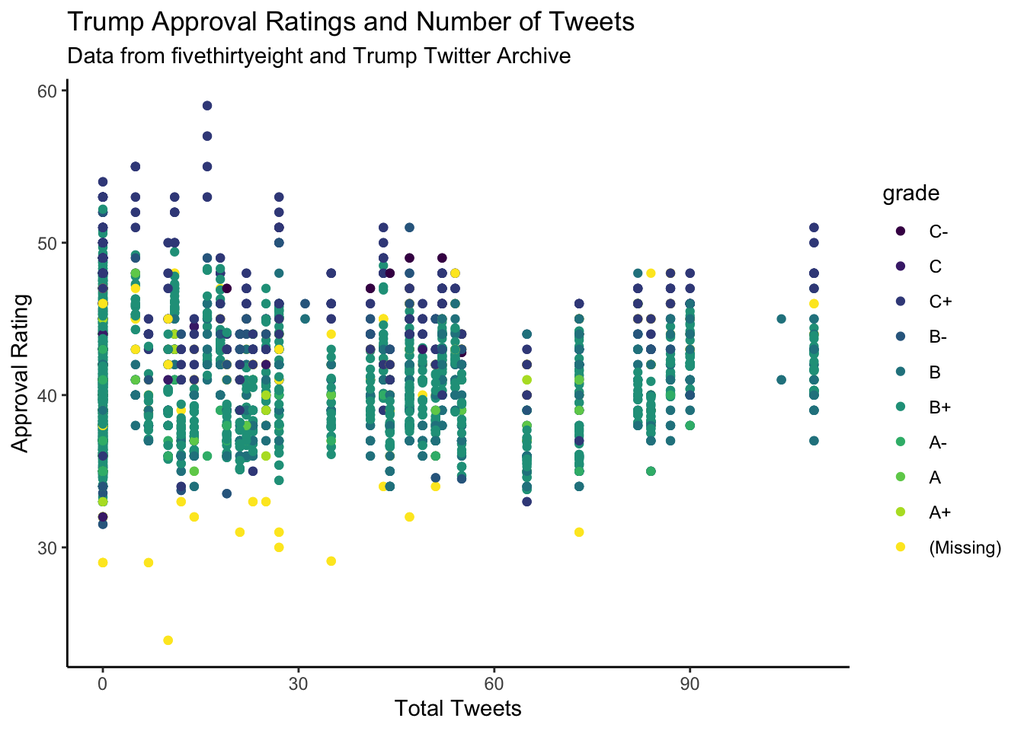

## Question 2: Run a multivariate regression

### 2A) Using lm()

The plot suggests that if I want to be able to interpret the effect of tweets on the approval rating, the grade of the poll will matter. Last week, we dealt with this problem by subsetting the data and only looking at Democrats. But with multiple regression, we can actually look at the effects of *multiple variables simultaneously*.

Create a variable “high_q” which takes a value of 1 if the poll is rated A+, A, or A-, and 0 if the rating is lower or missing.

Run a linear regression of `approve` on two variables: `total_tweets` and `high_q`, using `lm`. Tidy up your data, calling `term`, `estimate`, `conf.low`, and `conf.high`. Print a gt table with these values. Your table should look like something like this.

Effect of Number of Tweets and Poll Quality on Reported Approval Rating

| Data from fivethirtyeight and Trump Tweet Archive Variable | Data from fivethirtyeight and Trump Tweet Archive Estimate | Data from fivethirtyeight and Trump Tweet Archive Lower bound | Data from fivethirtyeight and Trump Tweet Archive Upper bound |
| --- | --- | --- | --- |
| (Intercept) | 41.603 | 41.462 | 41.7443 |
| total_tweets | -0.004 | -0.008 | -0.0003 |
| high_q | -2.347 | -2.792 | -1.9021 |

### 2B) Interpreting results

In one or two paragraphs (max 100 words for the whole answer), answer the following.

- What is the estimated **average treatment effect of high_q?** How would you, in words, describe the effect of a poll being high or low quality on the predicted approval rating? Remember that since this is multiple regression, your answer should explain how we should interpret the effect of high_q *in relation to the other variables in the regression*.
- What is the difference between the *frequentist* interpretation of the coefficients and the *Bayesian* interpretation?

### 2C) Interaction Variables

From our table in 2A, we can calculate the predicted effect of more tweets and the predicted effect of being high quality. But these estimates assume that we are holding constant the value of the other variable in the regression. What if we think that there is a specific effect of more tweets *on high quality polls*? Run a new regression, that includes total_tweets, high_q, and the *interaction* between total tweets and high quality. Print the new version of your above gt here.

### 2D) Estimating Fitted Values

From September 15 - September 19, 2017, Monmouth University ran a poll that was rated A+. That week, President Trump tweeted 84 times. Write out the formula that you would use to calculate the fitted value, or predicted approval rating for that poll, given the results in your interaction model from 2C. Then, check your work by pulling the relevant fitted value using the `augment` command or `predict`. Print the code you use so that we can see both methods. Note that your values may be off by a decimal point or two if you rounded the values in your tibble above.

### 2E) Multiple Regression and the Rubin Causal Model

Now, imagine that you are the president’s social media secretary, and it’s your job to figure out how whether his tweeting is having a positive or negative effect on his approval ratings. He is particularly interested on determining whether his tweeting has different effects on his approval ratings among republicans and democrats.

The president gives you full control over his Twitter for the next 12 weeks. You randomly assign weeks to receive high or low tweet volume. At the end of it, you want to run the following regression:

```r
randomized_approval <- approve ~ total_tweets + democrat + total_tweets:democrat
```

In 200 words, explain how you would interpret each of the three coefficients in this regression, using the Rubin Causal Model. If it’s helpful, you can make a mock Potential Outcomes table (but it’s not necessary). Remember to specifically explain how each coefficient should be interpreted *with respect to the other coefficients*. Is this an explanatory or predictive model?

## Question 3: Generalize to many regressions

One might reasonably wonder if the effect of President Trump’s tweet volume on his approval ratings changed over time. Create a new variable, month, using the following code:

```r
# Notice how similar this code is to the code that we used to create the "week"
# variable

poll$month <- ceiling(poll$week/4)
tweets$month <- ceiling(tweets$week/4)
```

We’re going to use our month variable to run a regression for each month, and use the results to replicate the graph below. **For this question, you do not need to replicate every design/formatting choice, but you must include all four graphs with proper labels**.

- First, prepare the dataset. Filter your poll data to use only the first 11 months. You can create the graphs on the right hand side using normal tidyverse functions (group_by, summarize, ggplot). The top right hand graph plots the average approval rating by month and poll quality, while the bottom right graph plots the total number of tweets by month.

For the left hand side, we recommend following the steps below:

- Pipe the data into `group_by(month)`, and then `nest()`, to create a tibble of tibbles. This tibble will have two columns, “month” and “data”, and 11 rows. Each row of the `data` column should be a list with all the observations for a given month.
- Create a column named `mod`, using `map()` to run `lm` on each row of your tibble. Run the same regression you did in 2A, using `total_tweets` and `high_q` as your explanatory variables (no interaction term).
- Create a column called `reg results`, using `map()` again to run tidy on the results. If you examine these results, you’ll see that for each “term” (in this case, “total_tweets”, “high_q”, and the intercept), it includes the term, the estimate, the standard error, the t statistic, and the p value. We’ll focus on the estimate and the standard error.
- Use `map_dbl()` to create columns for the estimate and standard error for your two variables of interest (`total_tweets` and `high_q`, and use those to create an `upper` and `lower` column for the 95% confidence interval for each variable. Note that this is an identical process to what you did in PS 7, just with multiple variables.
- Make plots of each of the coefficients.

Print your plots here. We like the “patchwork” package for arranging plots.

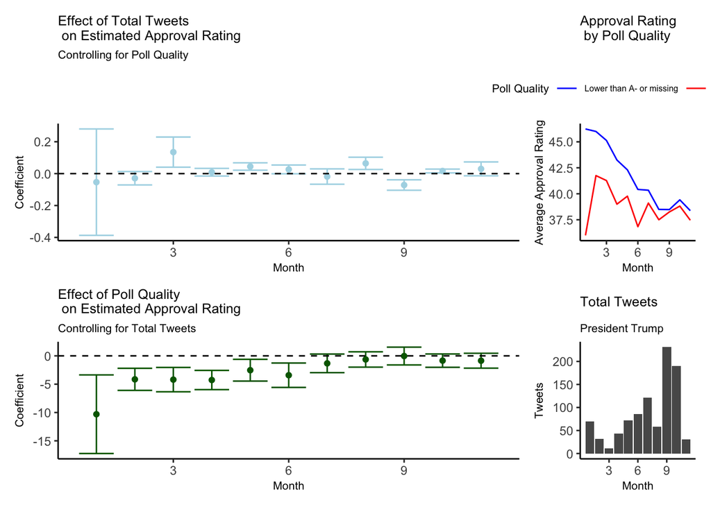